# Practical machine learning course project

## Executive summary

I use the data of the sports activities of 6 individuals to try to predict whether they did the exercises correctly or incorrectly, falling in 5 categories. As there are many predicting variables (50+) and the problem seems nonlinear, I build a random forest model. This has a high accuracy, around 94%, even in the test sample.

The data for this project come from this source: [http://groupware.les.inf.puc-rio.br/har](http://groupware.les.inf.puc-rio.br/har.)

## Loading and cleaning data

```r
library(caret)
library(dplyr)
activity_data<-read.csv("pml-training.csv", na.st=c("NA", ""))

# indicator of complete columns (as some variables have many missing values)
complete_column<-sapply(activity_data, function(x) sum(is.na(x)))==0

#drop columns with missing values
activity_full<-activity_data[,complete_column]

#check if some variables have very low variance, to drop these
nearZeroVar(activity_full)
```

```
## [1] 6
```

```r
#I drop the first 6 (names, etc), which are not relevant in the machine learning exercise
activity_full<-activity_full %>% select(-(1:6))
```

## Sampling

I divided the sample into a 70% training and 30% testing partition. But I also created a smaller (7%) training subsample to play around with, to choose among potential models (prediction trees, bagging, random forests).

```r
set.seed(33)
inTrain<-createDataPartition(y=activity_full$classe,p=0.7, list=FALSE)
training<-activity_full[inTrain,]
testing<-activity_full[-inTrain,]

#I also create a smaller training sample, because running the code on the full sample appeared to be very slow...
inTrain_small<-createDataPartition(y=activity_full$classe,p=0.07, list=FALSE)
training_small<-activity_full[inTrain_small,]
```

## Some exploratory data analysis

I tried to look for patterns in the pairwise plots (see an example below), but it seems that there are no discernible correlations: the connection between the explanatory variables and *classe* are not linear. That’s why I chose tree-models.

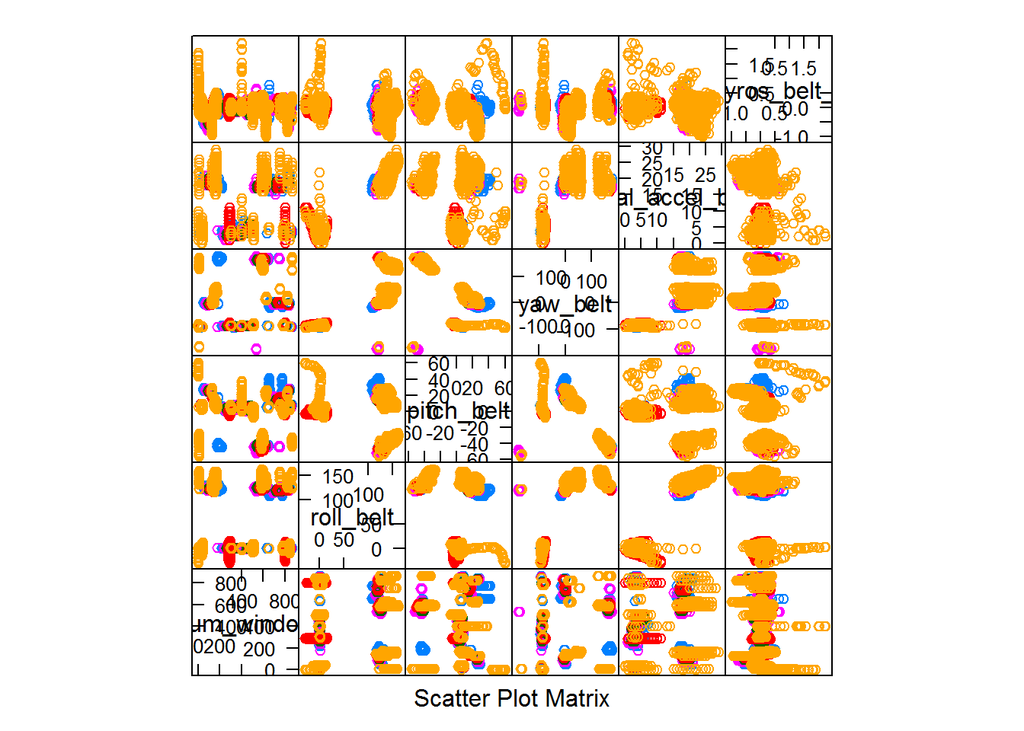

```r
featurePlot(x=training[,1:6], y=training$classe, plot="pairs")
```

## Random forest model

In the end, I found that a random forest model (see below) fits the small training data set (7%), as well as the training and test data surprisingly well. So I decided to stick with this. Running the random forest on a larger part of the sample (and doing more bootstraps) could probably add another 1-2%point to accuracy, but it was not worth the extra hours of running time for me, so I ran it on a relatively small sample.

```r
modFit<- train(classe ~ .,method="rf",data=training_small, prox=TRUE)
```

```r
pred_train<-predict(modFit, newdata=training)
#true versus predicted table in the training set
table(training$classe, pred_train)
```

```
##    pred_train
##        A    B    C    D    E
##   A 3869    8    5   10   14
##   B  163 2312  132   51    0
##   C    0  106 2280   10    0
##   D    2    4   83 2161    2
##   E    0   60   78   70 2317
```

```r
#accuracy
sum(diag(table(training$classe, pred_train)))/length(pred_train)
```

```
## [1] 0.9419087
```

```r
pred_test<-predict(modFit, newdata=testing)

#true versus predicted table in the test set
table(testing$classe, pred_test)
```

```
##    pred_test
##        A    B    C    D    E
##   A 1660    1    0    7    6
##   B   65  986   69   19    0
##   C    0   42  981    3    0
##   D    0    1   41  921    1
##   E    0   31   28   31  992
```

```r
#accuracy
sum(diag(table(testing$classe, pred_test)))/length(pred_test)
```

```
## [1] 0.9413764
```

Still, the accuracy is both 94% for the (full) training and test set! Thus on average, just **6% of the cases are expected to be misclassified**, even out of sample.

I also checked the importance of the explanatory variables. Below is the plot of the top 10.

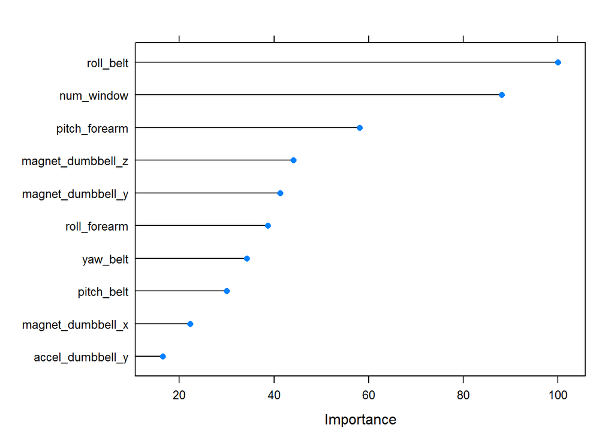

```r
importance<-varImp(modFit)
plot(importance, top=10)
```